# Model Based Clustering

So far we tried the usual distance based clustering techniques that assume spherical clusters and perform various distance based clustering techniques.

Parametric Clustering approach 1

### Model Based Clustering on the raw data

Now we will try a Bayesian approach that creates a probabilistic model approach of clustering data into mixtures of Gaussian distributions. this is done using model based clustering.

Setting up the data

```r
features <- read.csv('features_30_sec.csv')
num_features <- features[,!(names(features) %in% c("label", "filename"))]

df <- num_features

scaled_df <- scale(df, center = F)
```

```r
library(mclust)


mc_raw <-Mclust(df)
```

```
fitting ...
```

```r
summary(mc_raw)
```

```
----------------------------------------------------
Gaussian finite mixture model fitted by EM algorithm
----------------------------------------------------

Mclust XXX (ellipsoidal multivariate normal) model with 1 component:
```

|  | log-likelihood | n | df | BIC | ICL |
| --- | --- | --- | --- | --- | --- |
|  | -196267.7 | 1000 | 1769 | -404755.1 | -404755.1 |

```
Clustering table:
   1
1000
```

```r
mc_raw$BIC
```

```
Bayesian Information Criterion (BIC):
       EII      VII       EEI       VEI       EVI       VVI       EEE       VEE       EVE       VVE       EEV
1 -1577794 -1577794 -465040.4 -465040.4 -465040.4 -465040.4 -404755.1 -404755.1 -404755.1 -404755.1 -404755.1
2 -1517179 -1496524 -455709.0 -451156.7 -451938.6 -447654.2        NA        NA        NA        NA -409539.9
3 -1484562 -1451714 -447291.9 -444218.9 -438623.3 -436444.7        NA        NA        NA        NA -415134.3
4 -1457695 -1426933 -443943.9 -438308.2        NA -431055.0        NA        NA        NA        NA -419591.0
5 -1439332 -1406547 -440650.6 -435491.8        NA        NA        NA        NA        NA        NA -426612.7
6 -1429278 -1393143 -438215.0 -433982.0 -428853.6        NA        NA        NA        NA        NA -434734.2
7 -1424719 -1381153 -437147.5 -432142.7 -427538.0        NA        NA        NA        NA        NA -444696.2
8 -1412091 -1373170 -437073.9 -431624.7 -425745.6        NA        NA        NA        NA        NA -454557.5
9 -1407832       NA -435831.4 -429031.5 -425038.8        NA        NA        NA        NA        NA -465550.0
        VEV       EVV       VVV
1 -404755.1 -404755.1 -404755.1
2 -405655.6        NA        NA
3 -410194.0        NA        NA
4 -414299.2        NA        NA
5 -421695.1        NA        NA
6 -429727.2        NA        NA
7 -435942.3        NA        NA
8 -443003.1        NA        NA
9 -451434.8        NA        NA

Top 3 models based on the BIC criterion:
    EEE,1     EEV,1     EVE,1
-404755.1 -404755.1 -404755.1
```

This model has resulted in all the data being grouped into one single cluster. This only signifies the presence of redundant feature information that needs to be removed.

Lets try it on the scaled data

```r
#!!!!!!!!dont run this it will freeze
#mc_scaled <- Mclust(scaled_df)
```

This froze at 18%

Scaling the data did not help in allowing model based clustering to run. It in fact did not even run.

So we will need to reduce the dimension to allow any clustering

#### Part 1: Trying PCA on scaled data and then using Model Based clustering

```r
sum(proportion_variance_explained[1:15])
```

```
[1] 0.8636211
```

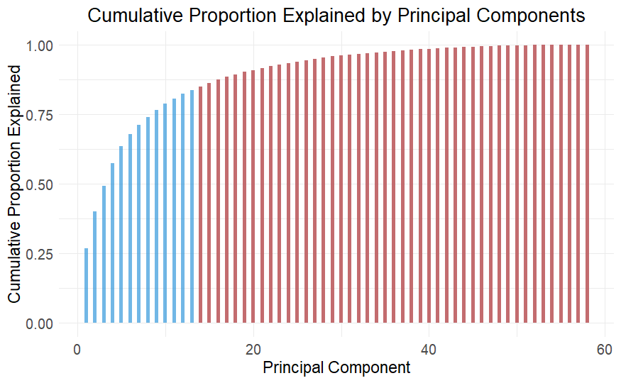

```r
library(ggplot2)
# Create a data frame for the scree plot
scree_data <- data.frame(
  Principal_Component = 1:length(proportion_variance_explained),
  Cumulative_Proportion_Explained = cumulative_proportion_explained
)

# Calculate the principal component index where cumulative variance reaches 85%
threshold_pc <- min(which(cumulative_proportion_explained >= 0.84))

# Create the scree plot using ggplot2 with improved aesthetics
ggplot(scree_data, aes(x = Principal_Component, y = Cumulative_Proportion_Explained)) +
  geom_bar(stat = "identity", fill = "#3498db", alpha = 0.7, width = 0.4) +  # Adjust width
  geom_bar(data = subset(scree_data, Principal_Component >= threshold_pc),
           aes(x = Principal_Component, y = Cumulative_Proportion_Explained),
           stat = "identity", fill = "#e74c3c", alpha = 0.7, width = 0.4) +  # Adjust width
  labs(x = "Principal Component", y = "Cumulative Proportion Explained") +
  ggtitle("Cumulative Proportion Explained by Principal Components") +
  theme_minimal() +
  theme(plot.title = element_text(size = 16, hjust = 0.5),
        axis.title = element_text(size = 14),
        axis.text = element_text(size = 12))
```

```r
ari_mc
```

```
[1] 0.1677635
```

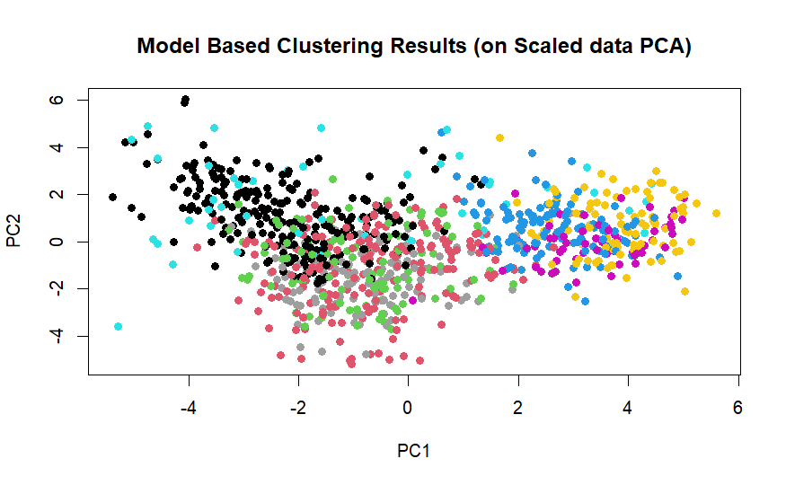

```r
plot(principal_components[,1:15], col=mc_dr_labels, pch=19,
     main = 'Model Based Clustering Results (on Scaled data PCA)')
```

```r
NA
NA
```

Using 15 principal components, the reduced dimension data is able to represnet 86% of the variation in the data set. The model based clustering on this data produces the following results:

```r
library(mclust)
set.seed(123)
model_based_clusters <- Mclust(principal_components[,1:15])
```

```
fitting ...
```

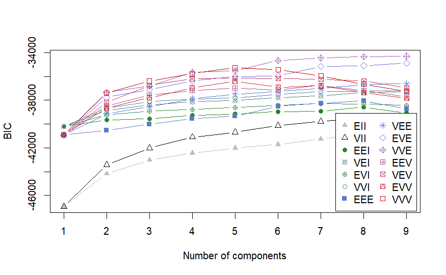

```r
View(results_df)
plot(model_based_clusters, what="BIC")
```

```r
model_based_clusters$G
```

```
[1] 9
```

Observations so far: 4 PC –> ARI: 12% (8 clusters) 5 PC –> ARI: 13% ( 9 clusters) 6 PC –> ARI: 14% ( 9 clusters) 8 PC –> ARI: 16% ( 9 clusters)

What I observed is that for different number of principal components considered, the number of clusters generated also changes. This implies an analysis to see how many components gives the best set of clusters

therefore an analysis is done by varying the number of principal components from 5 to 25, to see at which point the best model is found using the BIC.

```r
library(cluster)
library(mclust)
set.seed(123)

# Lists to store results
avg_silhouette_scores <- list()
ari_scores <- list()
num_clusters_list <- list()
best_bic_list <- list()

for (k in 5:25){
  mbc_data <- pca$x
  model_based_clusters <- Mclust(mbc_data[,1:k])

  # Calculate silhouette score
  silhouette_score <- silhouette(model_based_clusters$classification, dist(mbc_data[,1:k], "euclidean"))
  avg_silhouette_score <- mean(silhouette_score[,3])
  avg_silhouette_scores[[as.character(k)]] <- avg_silhouette_score

  # Calculate ARI
  ari_score <- adjustedRandIndex(model_based_clusters$classification, true_labels)
  ari_scores[[as.character(k)]] <- ari_score

  # Save number of clusters
  num_clusters <- length(unique(model_based_clusters$classification))
  num_clusters_list[[as.character(k)]] <- num_clusters

  # Save BIC of the best model
  best_bic <- max(model_based_clusters$bic)
  best_bic_list[[as.character(k)]] <- best_bic
}
```

[output not shown]

```r
# Combine results into data frame
results_df <- data.frame(
  "Number of Principal Components" = 5:25,
  "Number of Clusters" = unlist(num_clusters_list),
  "Avg Silhouette Score" = unlist(avg_silhouette_scores),
  "Best BIC" = unlist(best_bic_list)
  )

# Print the results data frame
print(results_df)
```

|  | Number.of.Principal.Components | Number.of.Clusters | Avg.Silhouette.Score | Best.BIC |
| --- | --- | --- | --- | --- |
| 5 | 5 | 9 | -0.1514296 | -111989.9 |
| 6 | 6 | 9 | -0.1210123 | -122834.1 |
| 7 | 7 | 9 | -0.1456454 | -135549.6 |
| 8 | 8 | 9 | -0.2470396 | -148152.5 |
| 9 | 9 | 6 | -0.2106800 | -160610.3 |
| 10 | 10 | 7 | -0.1322904 | -171907.5 |
| 11 | 11 | 8 | -0.2457777 | -183353.5 |
| 12 | 12 | 8 | -0.1782568 | -193794.3 |
| 13 | 13 | 6 | -0.2633023 | -205605.7 |
| 14 | 14 | 6 | -0.2805901 | -217703.8 |

[output cut: 11 more lines]

```r
NA
```

```r
library(cluster)
library(mclust)
set.seed(123)
model_based_clusters <- Mclust(principal_components[,1:19])

# Calculate silhouette score
silhouette_score <- silhouette(model_based_clusters$classification, dist(df, "euclidean"))
plot(silhouette_score)
sortSilhouette(silhouette_score)
mean(silhouette_score[,3])
# Print the silhouette score
print(silhouette_score)
```

[output not shown]

```r
library(mclust)
set.seed(123)
scaled_df <- scale(df, center = FALSE)
pca <- prcomp(scaled_df)
principal_components <- pca$x
model_based_clusters <- Mclust(principal_components[,1:15])
plot(model_based_clusters, what="BIC")
mbc_labels <- model_based_clusters$classification

table(mbc_labels,true_labels)

# Define the mapping of cluster numbers to colors
color_mapping <- c("red", "blue", "green", "orange", "purple", "yellow", "grey" ,"brown","black")

# Plot the cluster results
plot(principal_components[, 1:15], col = color_mapping[mbc_labels], pch = 19,
     main = 'Model Based Clustering Results (on Scaled data PCA)')

# Create the legend
legend("topright", legend = 1:9, col = color_mapping, pch = 19)
```

[output not shown]